# Panel Data: Event Studies, Difference in Differences, and Unobserved Effects

73-374 Econometrics II

## New Topic

**Panel Data**

## Adding group structure to data

- Up until now, we’ve assumed our data is drawn from a *random sample*
  - $(Y_i,X_i)$ independent and identically distributed
- In some types of data, this may not reflect the sampling process
- Our sample can consist of *groups* of related observations
- Call this structure **panel** or **longitudinal** **data**

## Example Panel Data Sets

- Individual or firm surveys visitng same respondents repeatedly
  - Panel Study of Income Dynamics
  - Longitudinal Business Database
- States, counties, or country characteristics over time
- Stock or financial asset prices and characteristics over time
  - CRSP, Compustat
- Household surveys
  - Can be grouped over time, also different members of same household

## Panel Structure

- In each example, observations within a group share characteristics
- If I ask “What is your favorite color?” then ask again 5 minutes later, answer unlikely to change very much
- Difficulty: can’t treat “you” and “you 5 minutes ago” as independent samples
  - “You” and “you 5 minutes ago” share many unobserved characteristics
- Advantage: can use differences **within** a group to learn about only those characteristics that *do* differ

## Answering Questions with Panel Data

- Effect of treatment on outcome, allowing treatment to vary within and between groups
  - Effect of state-level policy on employment or growth
  - Effect of firm announcements on stock prices
  - Effect of tax policy on individual outcomes and welfare

## Notation

- Observations in panel data indexed by 2 or more indices
  - one for unit/group: $i=1\ldots n$
  - one for observation within unit: $t=1\ldots T$
- Each unit $X_{i}=(X_{i,1},\ldots,X_{i,t},\ldots,X_{i,T})$
- $X_{i,t}$ may itself be a vector of characteristics
  - e.g. $(Income_{i,t}, age_{i,t}, \text{credit score}_{i,t}, \text{favorite color}_{i,t})$
- May be represented on computer as list of $N=n*T$ observations, one for each index $i$ and $t$ (e.g. “unit” and “time”)
- Or in special panel data format with $T$ observations in each group
  - Structure **pdata.frame** in library **plm** in R

## Event Studies

- Idea: compare outcomes within a unit before and after treatment
- So long as there are no systematic changes over time except for treatment, difference can be interpreted as causal
- $Y_{i,2}$ be outcome after treatment, $Y_{i,1}$ outcome before
- $\frac{1}{n}\sum_{i=1}^{n}(Y_{i,2}-Y_{i,1})$ estimates average effect
- Example: price of stock immediately before and after earnings announcement
- Equivalent to $\beta$ in regression
  $$Y_{i,t}=\beta_0+\beta*After_{t}+u_{i,t}$$
  - $After_{t}$ treatment is 1 if t=2, 0 if t=1

## Unobserved Effects Model

- Model outcome as $Y_{i,t}=\beta_0+\beta*After_{t} + a_i + u_{i,t}$
  - $u_{i,t}$ is nonsystematic variation in outcome
  - $E[u_{i,t}After_{t}]=0$ means no unobserved factors changing over time on average
  - $a_i$ is unit-specific characteristics that don’t change over time
  - $a_i$ called a **fixed effect** or **unobserved effect**
  - Accounts for any possible covariates so long as they are fixed over time
- Obtain $\frac{1}{n}\sum_{i=1}^{n}(Y_{i,2}-Y_{i,1})=\beta+\frac{1}{n}\sum_{i=1}^{n}(u_{i,2}-u_{i,1})$
- Unbiased and consistent estimator of $\beta$

## When to trust event studies

- Event Study methodology takes care of selection on characteristics that *don’t* change with time
- Doesn’t take care of things that do
  - Need there to be no other systematic changes at same time
- Effectively need *conditionally* random assignment given $a_i$
- Often reasonable with financial data: $t=2,t=1$ are in very short window right before and after:
  - No news aside from treatment (firm announces its earnings, stock is split, Fed announces new monetary policy) in very short window
- Can become unreasonable if any systematic changes over time

## Extensions

- Can account for observed differences between treatment and control periods by including observed unit-specific controls $X_{i,t}$
- Can also look at effect over multiple periods
  - Instead of just before and after, have $d\tau_t$, dummy variable equal to 1 if $t=\tau$, 0 otherwise
  - Called a **time dummy** or **time fixed effect**
- Run regression
  $$Y_{i,t}=\beta_0+\sum_{\tau=2}^{T}\beta_{\tau} d\tau_t + X_{i,t}^{\prime}\gamma+u_{i,t}$$
- If event occurs at $t=2$, $\beta_{\tau}$ is effect at time $\tau$
- Can also include multiple periods before event with more time dummies

## Example: “Coups, Corporations, and Classified Information”

- Dube, Kaplan, Naidu (Quarterly Journal of Economics 2011) look at returns of stocks of politically connected firms in countries before and after day CIA secretly authorizes coup d’etat in that country
- If no insider trading, and no important news released on day decision made, stock prices should be unaffected
- If systematic effect exists, suggest CIA insiders trading off of knowlege of coup plan
- Control for known observed factors predicting stock returns
- Event study means don’t need to worry that politically connected stocks different: just different on the day of coup authorization

## Specification

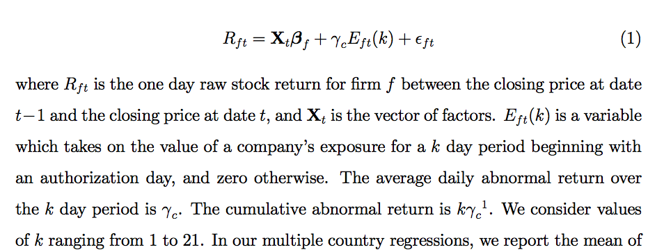

Specification reported in paper

## Results

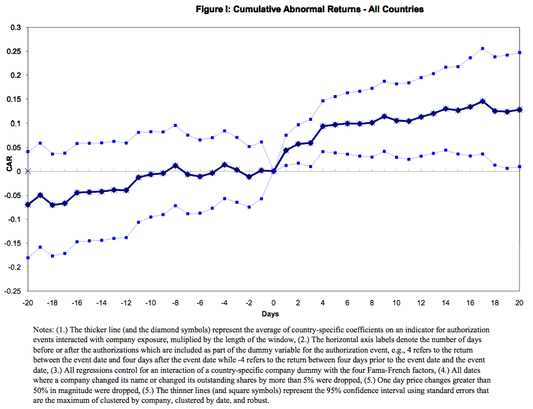

Results

## Event Study Limitations

- Outcome $Y_{i,t}$ observed at two times
  - Before and after an event
- Difference before and after
  $$\frac{1}{n}\sum_{i=1}^{n}Y_{i,2}-\frac{1}{n}\sum_{i=1}^{n}Y_{i,1}$$
- Measures effect of event
- Controls for selection bias caused by unobserved heterogeneity in level of $Y_i$ across $i$
- Doesn’t get rid of selection bias caused by changes over time other than the event of interest

## Accounting for systematic time variation

- In general, all sorts of things are happening at the same time as a treatment changes
- Outcome may be trending up or down over time for reasons unrelated to the treatment
- If these are not observed, can’t control for them directly
- Often, we can control for them indirectly
- Idea: Suppose two units experience same time-varying influences, but only one gets treatment in second period
  - **Common trends assumption**
- We can then compare change in treated to change in untreated unit

## Differences in Differences

- **Difference-in-differences** estimator compares difference in pre-and post-treatment outcomes among treated units to difference among units that don’t receive treatment
- Equivalent to comparing difference between treatment and control units after treatment occurs to difference before
- Difference between pre and post treatment outcomes controls for unit-specific fixed effects
- Difference between units controls for unobserved common time trends

## Estimator

- Baseline value is $\beta_0$ in control group,
  - Estimable by pre-treatment average $\bar{Y}_{1,control}$,
- Treatment group differs in baseline period by $\beta_1$
  - $\bar{Y}_{1,treat}$ estimates $\beta_1+\beta_0$
- Effect of time is $\delta_0$ on treatment and control units
  - $\bar{Y}_{2,control}$ estimates $\beta_0+\delta_0$
- Treatment effect is $\delta_1$
  - $\bar{Y}_{2,treat}$ estimates $\beta_0+\delta_0+\beta_1+\delta_1$
    $$\widehat{\delta}_1=(\bar{Y}_{2,treat}-\bar{Y}_{2,control})-(\bar{Y}_{1,treat}-\bar{Y}_{1,control})$$
    $$=(\bar{Y}_{2,treat}-\bar{Y}_{1,treat})-(\bar{Y}_{2,control}-\bar{Y}_{1,control})$$

## Table of outcomes

| Time / Unit | Before | After | After-Before |
| --- | --- | --- | --- |
| Control | $\beta_0$ | $\beta_0+\delta_0$ | $\delta_0$ |
| ———– | ——— | —————— | ———— |
| Treatment | $\beta_0+\beta_1$ | $\beta_0+\delta_0 +\beta_1+\delta_1$ | $\delta_0+\delta_1$ |
| ———– | ——— | —————— | ———— |
| Treatment - Control | $\beta_1$ | $\beta_1+\delta_1$ | $\delta_1$ |

## Example: Minimum wage in New Jersey and Pennsylvania

- Card & Krueger (1994) study effect of rise in New Jersey minimum wage on employment in fast food restaurants
- NJ raised minimum wage from $4.25 to $5.05 in 1992
  - PA kept it the same
- Compare employment in fast food stores near the border to control for common trends in employment
  - e.g. business cycle effects
- Need to believe that NJ not growing faster/slower than PA

## Employees per store by state and time (Card & Krueger Table 3)

| Time / Unit | 1991 | 1992 | After-Before |
| --- | --- | --- | --- |
| PA | 23.33 | 21.17 | -2.16 |
| ———– | ——— | —————— | ———— |
| NJ | 20.44 | 21.03 | 0.59 |
| ———– | ——— | —————— | ———— |
| NJ - PA | -2.89 | -0.14 | 2.76 |

## Regression Representation

- Treat observations with same $i$ but different $t$ as different observations
- Run OLS on “sample” of size $nT$
- Recall regression model for event study
  $$Y_{i,t}=\beta_0+\beta After_{t}+u_{i,t}$$
- Dif-in-dif also has equivalent representation as a regression
  $$Y_{i,t}=\beta_0+\beta_1*Treat_{i}+\delta_0*After_{t}+\delta_1*Treat_{i}*After_{t}+u_{i,t}$$
  - $Treat_{i}$ is 1 if unit is the one that will get treated, in any time
  - $After_{t}$ is 1 in the latter time period, 0 before
  - $Treat_{i}*After_{t}$ interaction indicates post-treatment difference
- So long as $u_{i,t}$ independent over time and groups, just OLS
  - Same estimation, inference, properties
  - Within-group heterogeneity absorbed into averages
- Also allows adding observable controls $X_{i,t}$

## More than 2 periods

- If observed over many periods, have many more options
- Simplest: combine outcomes from before periods, from after, and do standard DD estimate
- If treatment has constant effect, let $Treat_{i,t}=1$ if treatment active in unit $i$ at time $t$, 0 otherwise
  - Same as $Treat_{i}*After_{t}$ in 2 period case
- Use complete set of dummies $d\tau_{t}$ for periods, $dk_{i}$ for units
- Run
  $$Y_{i,t}=\beta_0+\delta_1*Treat_{i,t}+\sum_{\tau=2}^{T}\delta_{\tau}d\tau_{t}+\sum_{i=2}^{n}\beta_k dk_{i}+u_{i,t}$$

## Heterogeneous trends

- With many periods, can allow trends to differ between units
- Just need that trend is smooth
  - Takes fewer parameters to describe than time periods
  - E.g., linear trends (intercept+slope) need 3 or more time periods
- Regression representation
  $$Y_{i,t}=\beta_0+\delta_1*Treat_{i,t}+\sum_{\tau=2}^{T}\delta_{\tau}d\tau_{t}+\sum_{i=2}^{n}\beta_k dk_{i}+\sum_{i=2}^{n}\theta_k (dk_{i}\times t)+u_{i,t}$$
- Permits, e.g., employment to be growing faster in some states, so long as there is not a discontinuous break at treatment date

## Visualization (Code 1)

```r
# Plotting software for overlay graphics
library(ggplot2)
xg<-seq(0,16,1) #x grid
#Generate functions
difdif1=function(x){
  2+1.5*sin(0.5*x)+1*1+4*1*(x>=8)+0.5*x*1
}
difdif0=function(x){
  2+1.5*sin(0.5*x)+1*0+4*0*(x>=8)+0.5*x*0
}
y1<-difdif1(xg)
y2<-difdif0(xg)
```

## Visualization (Code 2)

```r
frame<-data.frame(xg,y1,y2) #Group in one data set

graph<-ggplot(data=frame,aes(x=xg))+
    geom_line(aes(y=y1),color="blue")
  +geom_line(aes(y=y2),color="red")
  + ylab("Outcome") + xlab("Time")
  +ggtitle("Differing Trends and Baselines:
           Blue line treated after t=8")
graph #Display Graph
```

## Visualization

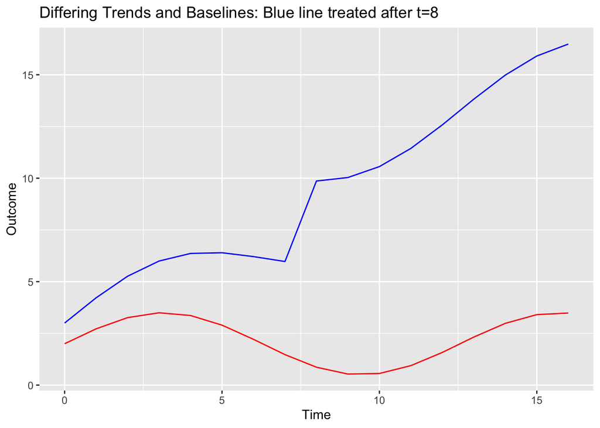

## Sampling Issues

- Sampling assumption for panel data: $X_{i}=(X_{i,1},\ldots,X_{i,t},\ldots,X_{i,T})$ drawn randomly (i.i.d.) from population of *groups*
- If we treat $X_i$ as a length-T vector, this is exactly random sampling as usual
- Law of large numbers, Central Limit Theorem continue to apply
  - $\frac{1}{n}\sum_{i=1}^{n}f(X_i)\overset{p}{\rightarrow}E[f(X_i)]$
  - $\frac{1}{\sqrt{n}}\sum_{i=1}^{n}f(X_i)\overset{d}{\rightarrow}N(E[f(X_i)],Var(f(X_i)))$
- Only thing to be careful of: sample size is $n$, not $N=n*T$
- Given this, can treat it like any other random sample we’ve seen so far in class
- Difference is we allow correlation *within* a unit

## Standard error issue: Serial correlation

- In general, if $u_{i,t}$ i.i.d. over $i$ AND $t$, *can* use standard (or robust) OLS inference
  - Unit-level covariates account for ALL persistence within groups
  - Use **lm()** command on $N=n*T$ independent observations
- With multiple periods, might have that $E[u_{i,s},u_{i,t}]\neq 0$
  - Unobserved factors may affect outcome over time
  - Called **serial correlation**
- Solution is to use SE formula which allows correlation over time within units
  - Called **clustered** (by unit) standard errors
- A formula that looks like (and is derived same way as) sandwich formula can do this
- Use **plm** package with **vcovHC** command, **cluster** option
- Effective sample size becomes $n$ instead of $nT$: SEs usually much bigger

## General framework

- Would like to deal with regressors more complicated than $before$ and $after$ some event
- Move from binary treatment $X=1$ or $X=0$ framework to general regression framework
- Will need to take fixed effects into account directly

## Fixed effects model

- Linear model with fixed effects
  $$Y_{i,t}=X_{i,t}^{\prime}\beta+\gamma_t+a_i+u_{i,t}$$
- $X_{i,t}=(X_{i,t,1},\ldots,X_{i,t,k})$ are regressors whose effect we care about
- $a_i$ are (group) fixed effects: not observed
- $\gamma_t$ are time fixed effects
- This is structural equation
  - Describes what would happen if $X$ set at some level
- Care about $\beta$: effect of our $X$ variables on outcome
- If $X$ is indicator of treatment, $\beta$ can be estimated by previous methods

## How do we estimate coefficients in Fixed Effects model?

- Can represent $\gamma_t$ by $\gamma_{t}d\tau_t$
  - $d\tau_t=1$ if $t=\tau$, $d\tau_t=0$ if $t\neq\tau$
  - $T-1$ Time dummies (base period excluded)
  - Adds $T-1$ extra variables: small fixed number
- Rest depends on what we assume about $a_i$
- Can rewrite error term as $e_{i,t}=a_i+u_{i,t}$
- If $a_i$ correlated with $X_{i,t}$ and not observed, $E[e_{i,t}X_{i,t}]\neq 0$
- OLS regression of $Y_{i,t}$ on $X_{i,t}$ and time dummies not consistent
  - Essentially a missing variable problem
- Need to find way to get rid of $a_i$ and estimate without it

## First Differences

- Idea: run regression in *changes* instead of levels
- Start in $T=2$ case for simplicity
- Define *first difference operator* $\Delta$ as $\Delta X_2:=X_{2}-X_{1}$
- Apply to $Y_{i,t}=X_{i,t}^{\prime}\beta+\gamma_td\tau_t+a_i+u_{i,t}$
  $$\Delta Y_{i,2}=\Delta X_{i,2}^{\prime}\beta+\gamma_2\Delta\tau_2+\Delta a_i+ \Delta u_{i,2}$$
- Since $a_i$ same at times $t=2$ and $t=1$, $\Delta a_i=0$
  - Differenced equation doesn’t contain $a_i$
- *Anything* that doesn’t change over time disappears
  - Constant term in $X_{i,t}$ goes away
  - Any variable in $X_{i,t}$ that doesn’t move (fixed characteristics) disappears
- $\Delta d\tau_2$ becomes just a constant

## First differences, interpretation

- Result is a regression equation only in observable variables

$$\Delta Y_{i,2}=\gamma_2 + \Delta X_{i,2}^{\prime}\beta + \Delta u_{i,2}$$

- So long as this satisfies the OLS assumptions, can estimate it by OLS over the $n$ samples (not $nT=2n$)
- Can’t include any $\beta_j$ corresponding to constant or variables that don’t change over time
- Interpretation is simple
  - Regress *change* in outcome on *change* in regressors
- Constant term is average *growth* instead of level
- Residuals are unobserved factors leading to *changes* in outcome
- Exogeneity means changes in regressor uncorrelated with changes in unobserved factor across units
- If $X_{i,t}$ is just a binary treatment, its coefficient is the difference-in-differences estimator

## Example: Chetty et al 2015

- Consider effect of geographic area on wages
- People who live in one city probably not the same as those who live in another
- Fixed effects account for that
- FD estimator gives you change in wages for people who move from one city to another
- If people who move differ from general population, no problem
  - *so long as* differences have equal effect on wages in both cities
- Estimate causal effect *of moving*
- But if other wage-relevant individual characteristics change at same time as move, then can’t distinguish

## Time invariant characteristics

- Suppose demographic used as part of $X_{i,t,j}$
  - In most cases, these are constant
- Effect of variables on outcome *not identified*
  - Because it never changes
- Don’t know if it’s, say, race or some other unchanging personal characteristic which leads to base level
- If you do include something like this, it will be set as NA
  - As in multicollinearity case

## Multiple Time Periods

- If $T>2$, can take differences $\Delta$ between $t=2$ and $t=1$, between $t=3$ and $t=2$, etc.
- Applied to $Y_{i,t}=X_{i,t}^{\prime}\beta+\gamma_td\tau_t+a_i+u_{i,t}$ get
  $$\Delta Y_{i,t}=\gamma_t d\tau_t + \Delta X_{i,t}^{\prime}\beta + \Delta u_{i,t}$$
- for $i=1\ldots n$, $t=2\ldots T$
- Treat each $(i,t)$ as an observation: have $n(T-1)$ samples
- Estimate by OLS
- $a_i$ disappears due to differencing
- Again we lose any $X_{i,t}$ which doesn’t change over time

## Next Time

- More about panel data:
  - Fixed Effects
  - Random Effects
- Read Wooldridge Ch 13-14